# Amazon Delivery Performance Analysis

Medine Yazıcı

2025-05-09

## 1. Aim of the Project

The main purpose of this project is to examine the factors affecting delivery time in Amazon’s last-mile delivery processes. The dataset used in the project includes detailed information on over 43,000 orders. It covers many variables such as order time, pick-up time, weather and traffic conditions, type of delivery vehicle, delivery area, product category, and characteristics of the agent performing the delivery.

In the analysis process, delivery time is measured in minutes as a performance metric. The project aims to identify the variables affecting the efficiency of delivery and to evaluate a model that explains the main elements impacting the delivery process through statistical modeling in this direction. In addition, the goal is to obtain data-based insights to make Amazon’s delivery performance more efficient by visualizing and interpreting the findings obtained from the analysis.

## 2. Source of the Data and Variables

The dataset utilized in this project is called the “Amazon Delivery Dataset,” which was published on the Kaggle platform and sourced from an open data repository. It contains 43,739 observations related to Amazon’s last-mile delivery processes. It includes variables concerning order details, logistics operations information, environmental conditions, and delivery times.

The variables included in the dataset are as follows:

**Order_ID:** A unique ID number assigned to each order.

**Agent_Age:** The age of the delivery agent performing the delivery.

**Agent_Rating:** The rating of the delivery agent given by the customer.

**Store_Latitude & Store_Longitude:** The latitude and longitude coordinates of the store which the order was picked up.

**Drop_Latitude & Drop_Longitude:** The latitude and longitude coordinates of the point where the order was delivered.

**Order_Date:** The date the order was placed.

**Order_Time:** The time the order was placed.

**Pickup_Time:** The time at which the order was picked up by the delivery agent.

**Weather:** The weather conditions observed during the delivery.

**Traffic:** The traffic density encountered during the delivery.

**Vehicle:** The type of vehicle used for the delivery.

**Area:** The type of area where the delivery was made.

**Delivery_Time:** The duration (in minutes) from the moment the order was picked up to when it reached the customer.

**Category:** Category of the ordered product.

In this project, the *‘Delivery_Time’* variable is determined as the dependent variable. It directly represents the delivery time in minutes and is considered the key performance indicator to measure delivery efficiency.

## 3. Data Cleaning and Tidying

```r
library(tidyverse)
amazon <- read_csv("amazon_delivery.csv")
amazon <- amazon %>% select(-Order_ID)
str(amazon)
```

```
## tibble [43,739 × 15] (S3: tbl_df/tbl/data.frame)
##  $ Agent_Age      : num [1:43739] 37 34 23 38 32 22 33 35 22 36 ...
##  $ Agent_Rating   : num [1:43739] 4.9 4.5 4.4 4.7 4.6 4.8 4.7 4.6 4.8 4.2 ...
##  $ Store_Latitude : num [1:43739] 22.7 12.9 12.9 11 13 ...
##  $ Store_Longitude: num [1:43739] 75.9 77.7 77.7 77 80.2 ...
##  $ Drop_Latitude  : num [1:43739] 22.8 13 12.9 11.1 13 ...
##  $ Drop_Longitude : num [1:43739] 75.9 77.8 77.7 77 80.3 ...
##  $ Order_Date     : Date[1:43739], format: "2022-03-19" "2022-03-25" ...
##  $ Order_Time     : chr [1:43739] "11:30:00" "19:45:00" "08:30:00" "18:00:00" ...
##  $ Pickup_Time    : 'hms' num [1:43739] 11:45:00 19:50:00 08:45:00 18:10:00 ...
##   ..- attr(*, "units")= chr "secs"
##  $ Weather        : chr [1:43739] "Sunny" "Stormy" "Sandstorms" "Sunny" ...
##  $ Traffic        : chr [1:43739] "High" "Jam" "Low" "Medium" ...
##  $ Vehicle        : chr [1:43739] "motorcycle" "scooter" "motorcycle" "motorcycle" ...
##  $ Area           : chr [1:43739] "Urban" "Metropolitian" "Urban" "Metropolitian" ...
##  $ Delivery_Time  : num [1:43739] 120 165 130 105 150 130 200 160 170 230 ...
##  $ Category       : chr [1:43739] "Clothing" "Electronics" "Sports" "Cosmetics" ...
```

The dataset contains a total of 16 variables, each falling into distinct types based on their nature and role in analysis. Among them, 7 variables are numerical, including continuous measures such as *Agent_Age, Agent_Rating, Store_Latitude, Store_Longitude, Drop_Latitude, Drop_Longitude*, and the target variable *Delivery_Time*. These variables are essential for quantitative analysis and can be used directly in regression-based modeling.

The dataset also includes 2 time-related variables, *Order_Time and Pickup_Time*, stored as strings but semantically representing times of day. These will be converted into proper time formats for time-based feature engineering. Additionally, *Order_Date* will be transformed into a Date type.

```r
head(amazon)
```

```
## # A tibble: 6 × 15
##   Agent_Age Agent_Rating Store_Latitude Store_Longitude Drop_Latitude
##       <dbl>        <dbl>          <dbl>           <dbl>         <dbl>
## 1        37          4.9           22.7            75.9          22.8
## 2        34          4.5           12.9            77.7          13.0
## 3        23          4.4           12.9            77.7          12.9
## 4        38          4.7           11.0            77.0          11.1
## 5        32          4.6           13.0            80.2          13.0
## 6        22          4.8           17.4            78.4          17.5
## # ℹ 10 more variables: Drop_Longitude <dbl>, Order_Date <date>,
## #   Order_Time <chr>, Pickup_Time <time>, Weather <chr>, Traffic <chr>,
## #   Vehicle <chr>, Area <chr>, Delivery_Time <dbl>, Category <chr>
```

```r
summary(amazon)
```

```
##    Agent_Age      Agent_Rating   Store_Latitude   Store_Longitude
##  Min.   :15.00   Min.   :1.000   Min.   :-30.90   Min.   :-88.37
##  1st Qu.:25.00   1st Qu.:4.500   1st Qu.: 12.93   1st Qu.: 73.17
##  Median :30.00   Median :4.700   Median : 18.55   Median : 75.90
##  Mean   :29.57   Mean   :4.634   Mean   : 17.21   Mean   : 70.66
##  3rd Qu.:35.00   3rd Qu.:4.900   3rd Qu.: 22.73   3rd Qu.: 78.05
##  Max.   :50.00   Max.   :6.000   Max.   : 30.91   Max.   : 88.43
##                  NA's   :54
##  Drop_Latitude   Drop_Longitude    Order_Date          Order_Time
##  Min.   : 0.01   Min.   : 0.01   Min.   :2022-02-11   Length:43739
##  1st Qu.:12.99   1st Qu.:73.28   1st Qu.:2022-03-04   Class :character
##  Median :18.63   Median :76.00   Median :2022-03-15   Mode  :character
##  Mean   :17.46   Mean   :70.82   Mean   :2022-03-13
##  3rd Qu.:22.79   3rd Qu.:78.10   3rd Qu.:2022-03-27
##  Max.   :31.05   Max.   :88.56   Max.   :2022-04-06
##
##  Pickup_Time         Weather            Traffic            Vehicle
##  Length:43739      Length:43739       Length:43739       Length:43739
##  Class1:hms        Class :character   Class :character   Class :character
##  Class2:difftime   Mode  :character   Mode  :character   Mode  :character
##  Mode  :numeric
##
##
##
##      Area           Delivery_Time     Category
##  Length:43739       Min.   : 10.0   Length:43739
##  Class :character   1st Qu.: 90.0   Class :character
##  Mode  :character   Median :125.0   Mode  :character
##                     Mean   :124.9
##                     3rd Qu.:160.0
##                     Max.   :270.0
##
```

Based on the summary of the dataset, notably the variable *Agent_Rating* contains 54 missing values. The *Order_Date* variable is correctly recognized as a Date type, making it ready for temporal analyses or feature engineering if necessary.

All categorical variables, including *Weather, Traffic, Vehicle, Area, and Category*, are currently stored as character strings. These should be converted to factor types for proper usage in visualizations and modeling.

Moreover, *Traffic* can be treated as an ordinal variable, with levels such as “Low”, “Medium”, “High”, and “Jam” implying a natural order.

```r
missing_keywords <- c("NA", "NaN", "None", "Na", "")
sapply(amazon, function(column) {
  sum(is.na(column) | column %in% missing_keywords)
})
```

```
##       Agent_Age    Agent_Rating  Store_Latitude Store_Longitude   Drop_Latitude
##               0              54               0               0               0
##  Drop_Longitude      Order_Date      Order_Time     Pickup_Time         Weather
##               0               0              91               0              91
##         Traffic         Vehicle            Area   Delivery_Time        Category
##              91               0               0               0               0
```

In the initial summary output, only the *Agent_Rating* variable appeared to contain missing values. However, by conducting a more thorough check that included non-standard missing indicators such as “NaN”, “None”, “Na”, “NA”, and empty strings, additional missingness was identified in the *Order_Time, Weather, and Traffic* variables. This highlights the importance of going beyond basic summaries to capture all potential sources of data quality issues before moving on to analysis.

### Missing Value Detection

```r
amazon %>%
  filter(Order_Time == "NaN" & Weather == "NaN" & Traffic == "NaN") %>%
  select(Order_Time, Weather, Traffic)
```

```
## # A tibble: 91 × 3
##    Order_Time Weather Traffic
##    <chr>      <chr>   <chr>
##  1 NaN        NaN     NaN
##  2 NaN        NaN     NaN
##  3 NaN        NaN     NaN
##  4 NaN        NaN     NaN
##  5 NaN        NaN     NaN
##  6 NaN        NaN     NaN
##  7 NaN        NaN     NaN
##  8 NaN        NaN     NaN
##  9 NaN        NaN     NaN
## 10 NaN        NaN     NaN
## # ℹ 81 more rows
```

During the data cleaning process, missing values were detected in several key variables including *Order_Time, Weather, and Traffic*. Upon closer inspection, it was found that these three variables tend to be missing simultaneously within the same observations. In other words, whenever a record has a missing value for *Order_Time*, the values for both *Weather* and *Traffic* are also missing.

```r
amazon <- amazon %>%
  mutate(across(c(Order_Time, Weather, Traffic), ~na_if(., "NaN")))

colSums(is.na(amazon[c("Agent_Rating","Order_Time", "Weather", "Traffic")]))
```

```
## Agent_Rating   Order_Time      Weather      Traffic
##           54           91           91           91
```

In the data cleaning process, four variables were identified as containing missing values: *Agent_Rating, Order_Time, Weather, and Traffic*. While the missing values in *Agent_Rating* were already properly encoded as NA in R, the other three variables contained the string “NaN” instead of recognized missing values. To ensure consistency and proper handling of missingness, these “NaN” strings were converted to NA using the na_if() function in R. After this cleaning step, the dataset correctly reports 91 missing observations in each of *Order_Time, Weather, and Traffic*, and 54 in *Agent_Rating*.

### Data Type Conversion

```r
library(dplyr)
library(hms)
amazon <- amazon %>%
  mutate(
    Order_Date = as.Date(Order_Date),
    Order_Time = as_hms(Order_Time),
    Pickup_Time = as_hms(Pickup_Time),
    Delivery_Time = as.numeric(Delivery_Time),
    Agent_Rating = as.numeric(Agent_Rating)
  )

amazon <- amazon %>%
  mutate(
    Weather = as.factor(Weather),
    Traffic = as.factor(Traffic),
    Vehicle = as.factor(Vehicle),
    Area = as.factor(Area),
    Category = as.factor(Category)
  )

str(amazon)
```

```
## tibble [43,739 × 15] (S3: tbl_df/tbl/data.frame)
##  $ Agent_Age      : num [1:43739] 37 34 23 38 32 22 33 35 22 36 ...
##  $ Agent_Rating   : num [1:43739] 4.9 4.5 4.4 4.7 4.6 4.8 4.7 4.6 4.8 4.2 ...
##  $ Store_Latitude : num [1:43739] 22.7 12.9 12.9 11 13 ...
##  $ Store_Longitude: num [1:43739] 75.9 77.7 77.7 77 80.2 ...
##  $ Drop_Latitude  : num [1:43739] 22.8 13 12.9 11.1 13 ...
##  $ Drop_Longitude : num [1:43739] 75.9 77.8 77.7 77 80.3 ...
##  $ Order_Date     : Date[1:43739], format: "2022-03-19" "2022-03-25" ...
##  $ Order_Time     : 'hms' num [1:43739] 11:30:00 19:45:00 08:30:00 18:00:00 ...
##   ..- attr(*, "units")= chr "secs"
##  $ Pickup_Time    : 'hms' num [1:43739] 11:45:00 19:50:00 08:45:00 18:10:00 ...
##   ..- attr(*, "units")= chr "secs"
##  $ Weather        : Factor w/ 6 levels "Cloudy","Fog",..: 5 4 3 5 1 1 2 1 4 2 ...
##  $ Traffic        : Factor w/ 4 levels "High","Jam","Low",..: 1 2 3 4 1 2 2 4 2 2 ...
##  $ Vehicle        : Factor w/ 4 levels "bicycle","motorcycle",..: 2 3 2 2 3 2 3 2 2 2 ...
##  $ Area           : Factor w/ 4 levels "Metropolitian",..: 4 1 4 1 1 4 1 1 1 1 ...
##  $ Delivery_Time  : num [1:43739] 120 165 130 105 150 130 200 160 170 230 ...
##  $ Category       : Factor w/ 16 levels "Apparel","Books",..: 3 5 15 4 16 16 16 14 5 16 ...
```

```r
summary(amazon)
```

```
##    Agent_Age      Agent_Rating   Store_Latitude   Store_Longitude
##  Min.   :15.00   Min.   :1.000   Min.   :-30.90   Min.   :-88.37
##  1st Qu.:25.00   1st Qu.:4.500   1st Qu.: 12.93   1st Qu.: 73.17
##  Median :30.00   Median :4.700   Median : 18.55   Median : 75.90
##  Mean   :29.57   Mean   :4.634   Mean   : 17.21   Mean   : 70.66
##  3rd Qu.:35.00   3rd Qu.:4.900   3rd Qu.: 22.73   3rd Qu.: 78.05
##  Max.   :50.00   Max.   :6.000   Max.   : 30.91   Max.   : 88.43
##                  NA's   :54
##  Drop_Latitude   Drop_Longitude    Order_Date          Order_Time
##  Min.   : 0.01   Min.   : 0.01   Min.   :2022-02-11   Length:43739
##  1st Qu.:12.99   1st Qu.:73.28   1st Qu.:2022-03-04   Class1:hms
##  Median :18.63   Median :76.00   Median :2022-03-15   Class2:difftime
##  Mean   :17.46   Mean   :70.82   Mean   :2022-03-13   Mode  :numeric
##  3rd Qu.:22.79   3rd Qu.:78.10   3rd Qu.:2022-03-27
##  Max.   :31.05   Max.   :88.56   Max.   :2022-04-06
##
##  Pickup_Time             Weather       Traffic            Vehicle
##  Length:43739      Cloudy    :7288   High  : 4296   bicycle   :   15
##  Class1:hms        Fog       :7440   Jam   :13725   motorcycle:25527
##  Class2:difftime   Sandstorms:7245   Low   :14999   scooter   :14639
##  Mode  :numeric    Stormy    :7374   Medium:10628   van       : 3558
##                    Sunny     :7078   NA's  :   91
##                    Windy     :7223
##                    NA's      :  91
##             Area       Delivery_Time          Category
##  Metropolitian:32698   Min.   : 10.0   Electronics: 2849
##  Other        : 1138   1st Qu.: 90.0   Books      : 2824
##  Semi-Urban   :  152   Median :125.0   Jewelry    : 2802
##  Urban        : 9751   Mean   :124.9   Toys       : 2781
##                        3rd Qu.:160.0   Skincare   : 2772
##                        Max.   :270.0   Snacks     : 2770
##                                        (Other)    :26941
```

After identifying and handling missing values, we performed comprehensive data type transformations to ensure the dataset is clean and analysis-ready. Time-related variables such as *Order_Date, Order_Time*, and Pickup_Time were converted to appropriate date and time formats. Numerical fields like *Delivery_Time* and *Agent_Rating* were parsed as numeric values. Furthermore, all relevant categorical variables *(Weather, Traffic, Vehicle, Area, and Category)* were converted from character strings to factor variables to enable meaningful analysis and visualizations.

```r
amazon %>%
  select(Agent_Age, Agent_Rating, Delivery_Time) %>%
  summary()
```

```
##    Agent_Age      Agent_Rating   Delivery_Time
##  Min.   :15.00   Min.   :1.000   Min.   : 10.0
##  1st Qu.:25.00   1st Qu.:4.500   1st Qu.: 90.0
##  Median :30.00   Median :4.700   Median :125.0
##  Mean   :29.57   Mean   :4.634   Mean   :124.9
##  3rd Qu.:35.00   3rd Qu.:4.900   3rd Qu.:160.0
##  Max.   :50.00   Max.   :6.000   Max.   :270.0
##                  NA's   :54
```

The average age of delivery agents is approximately 29.57, with ages ranging from 15 to 50 years. The *Agent_Rating* variable ranges from 1.0 to 6.0, with a mean of 4.63 and a median of 4.7, suggesting that most agents receive relatively high performance ratings, though there are 54 missing values.

The *Delivery_Time* variable, which represents the delivery duration in minutes, ranges from 10 to 270 minutes, with a mean of approximately 125 minutes. The 1st and 3rd quartiles (90 and 160) show that most deliveries are completed within a 70-minute window, but some deliveries take significantly longer, possibly indicating delays due to factors like traffic or weather.

```r
sapply(amazon[c("Agent_Age", "Agent_Rating", "Delivery_Time")], sd, na.rm = TRUE)
```

```
##     Agent_Age  Agent_Rating Delivery_Time
##     5.8151554     0.3347164    51.9154513
```

The average delivery agent age is 29.6 years with a standard deviation of 5.82, indicating a fairly narrow spread around the mean. Agent ratings are concentrated around a high average of 4.63 with a low standard deviation of 0.33, suggesting that most agents receive consistently high scores, with 54 missing observations. The average delivery time is 125 minutes, but the standard deviation is 51.92, indicating substantial variability across deliveries. This spread may be influenced by external factors such as weather conditions, road traffic, or delivery distance.

### Exploratory Data Analysis (EDA)

#### * Histogram of Delivery Time

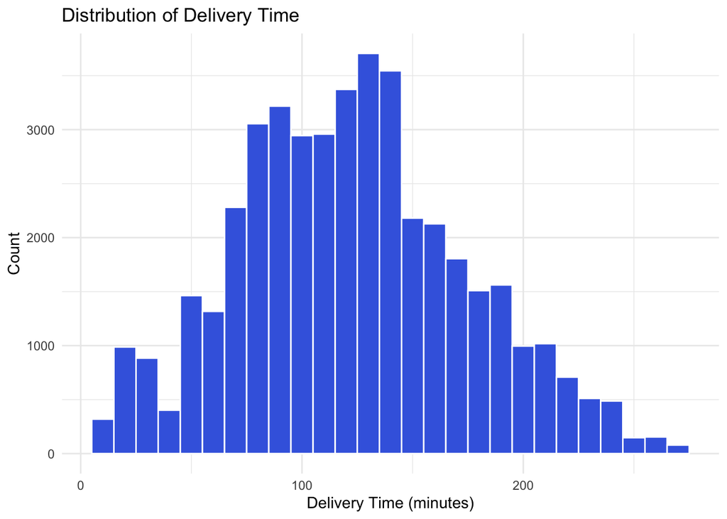

```r
library(ggplot2)

ggplot(amazon, aes(x = Delivery_Time)) +
  geom_histogram(binwidth = 10, fill = "royalblue", color = "white") +
  labs(title = "Distribution of Delivery Time", x = "Delivery Time (minutes)", y = "Count") +
  theme_minimal()
```

The histogram shows that most delivery times are concentrated between 90 and 160 minutes. The distribution is slightly right-skewed, indicating the presence of longer delivery times that may be considered outliers.

#### * Boxplot of Delivery Time

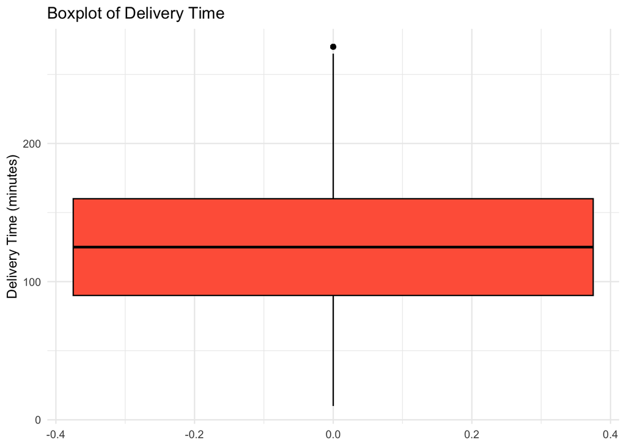

```r
ggplot(amazon, aes(y = Delivery_Time)) +
  geom_boxplot(fill = "tomato", color = "black") +
  labs(title = "Boxplot of Delivery Time", y = "Delivery Time (minutes)") +
  theme_minimal()
```

The boxplot shows that the majority of delivery times fall between approximately 90 and 160 minutes, with a median around 125 minutes. There is one visible outlier above 200 minutes, indicating that a small number of deliveries take significantly longer than usual. Overall, the distribution appears moderately spread, with a few potentially delayed deliveries.

#### * Correlation and Pairwise Relationships

```r
library(GGally)
```

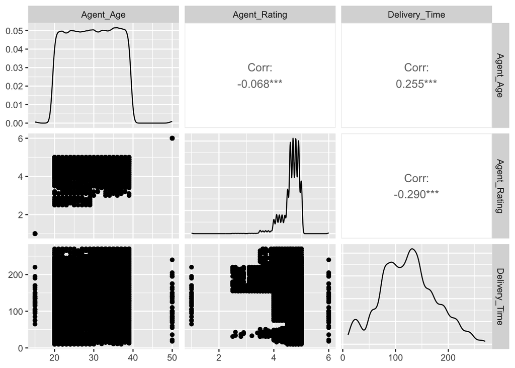

```r
amazon_numeric <- amazon %>%
  select(Agent_Age, Agent_Rating, Delivery_Time) %>%
  na.omit()

ggpairs(amazon_numeric)
```

A pairwise scatterplot matrix revealed that delivery time is moderately and negatively correlated with agent rating (–0.290), suggesting higher-rated agents tend to deliver faster. A weak positive correlation (0.255) was found between agent age and delivery time, implying older agents may take slightly longer. The relationship between agent age and rating was negligible (–0.068). Overall, while agent characteristics show some association with delivery performance, the effects are limited.

#### * Delivery Time by Traffic Conditions

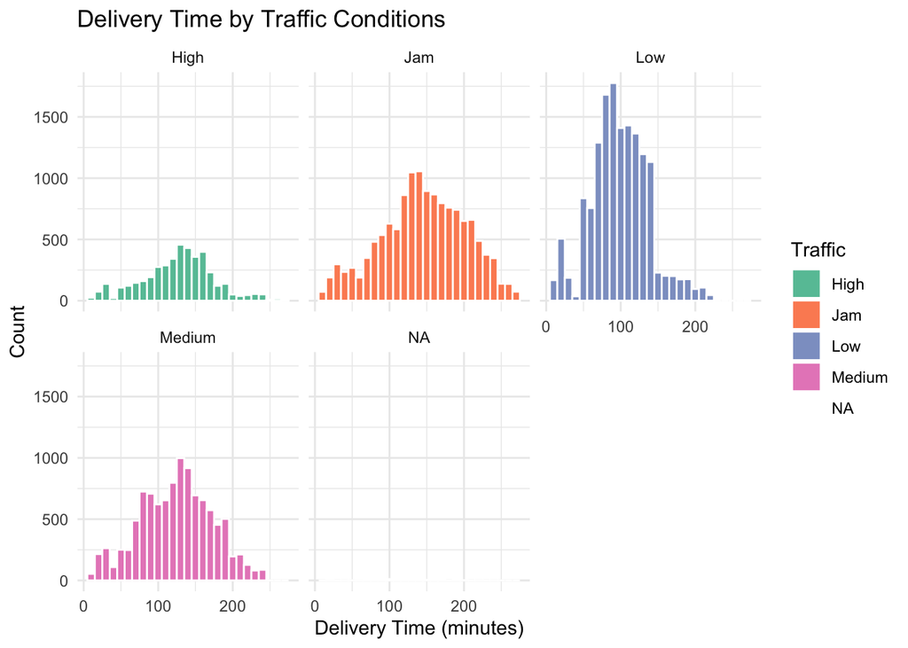

```r
ggplot(amazon, aes(x = Delivery_Time, fill = Traffic)) +
  geom_histogram(binwidth = 10, color = "white") +
  facet_wrap(~Traffic) +
  scale_fill_brewer(palette = "Set2") +  # Alternatif: "Pastel1", "Dark2", "Set3"
  theme_minimal() +
  labs(title = "Delivery Time by Traffic Conditions",
       x = "Delivery Time (minutes)",
       y = "Count")
```

#### * Delivery Time by Area

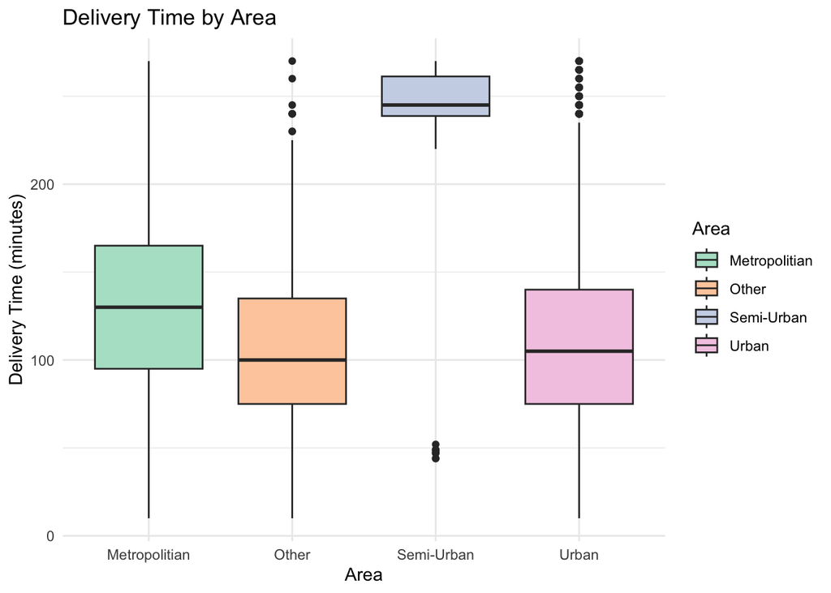

```r
ggplot(amazon, aes(x = Area, y = Delivery_Time, fill = Area)) +
  geom_boxplot() +
  scale_fill_brewer(palette = "Pastel2") +
  labs(title = "Delivery Time by Area", x = "Area", y = "Delivery Time (minutes)") +
  theme_minimal()
```

The boxplot compares delivery durations across different area types. Deliveries in Semi-Urban areas have the highest median time and the least variability, indicating consistently longer deliveries. In contrast, Other and Urban areas show lower median delivery times, with wider spreads and more variability. Metropolitan areas exhibit a moderate median but include many short deliveries, as indicated by the lower whisker. These differences suggest that geographical area plays a significant role in delivery efficiency

#### * Delivery Time Distribution by Weather

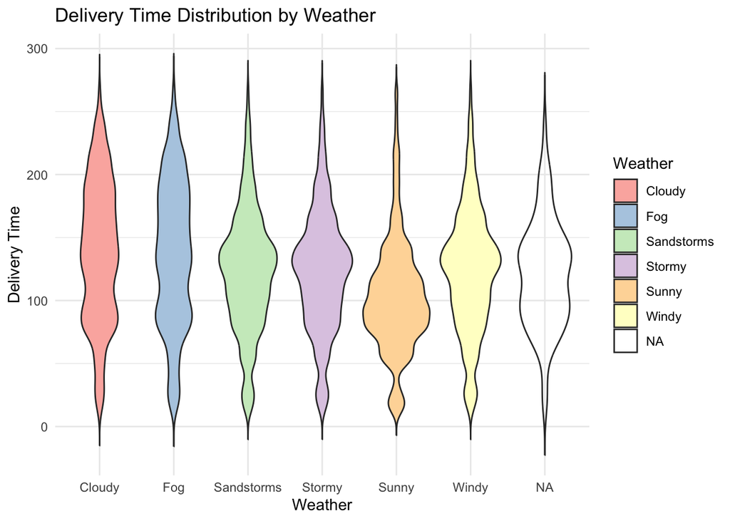

```r
ggplot(amazon, aes(x = Weather, y = Delivery_Time, fill = Weather)) +
  geom_violin(trim = FALSE) +
  scale_fill_brewer(palette = "Pastel1") +
  labs(title = "Delivery Time Distribution by Weather", x = "Weather", y = "Delivery Time") +
  theme_minimal()
```

#### * Missing Values

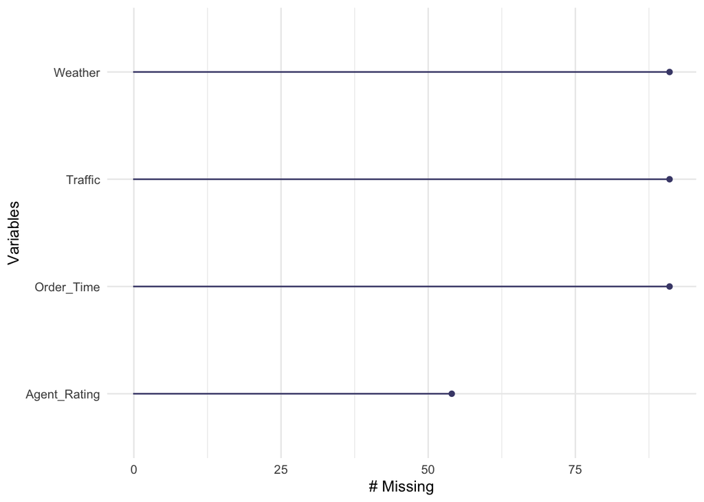

```r
library(naniar)
gg_miss_var(amazon[, c("Agent_Rating", "Order_Time", "Weather", "Traffic")])
```

The missing data visualization reveals that Order_Time, Weather, and Traffic each contain 91 missing values, while Agent_Rating has 54.

## 4. Missing Data Analysis and Imputation Strategy

There are missing values in four variables: *Agent_Rating* 54 missing, and *Order_Time*, *Weather*, and *Traffic* each with 91 missing.

The variables *Order_Time, Weather, and Traffic* are missing in the same rows. This pattern suggests that the delivery may not have been completed or recorded properly in those cases. Since their missingness seems related to the delivery situation, these variables are likely Missing At Random (MAR).

In contrast, *Agent_Rating* is missing in different rows and does not follow the same structure. This variable may represent a predefined score for the delivery agent. If the rating is not collected at the time of delivery but instead reflects an agent’s historical or average score, its absence might be due to system-level data entry issues or missing records for some agents. Therefore, the missing values in *Agent_Rating* are considered Missing Completely At Random (MCAR).

```r
library(mice)
```

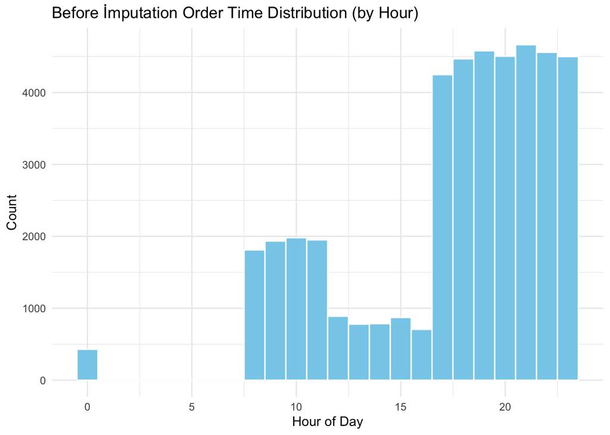

```r
library(lubridate)

amazon_raw_time <- amazon %>%
  mutate(Order_Hour = hour(as_hms(Order_Time)))

ggplot(amazon_raw_time, aes(x = Order_Hour)) +
  geom_histogram(binwidth = 1, fill = "skyblue", color = "white") +
  labs(title = "Before İmputation Order Time Distribution (by Hour)", x = "Hour of Day", y = "Count") +
  theme_minimal()
```

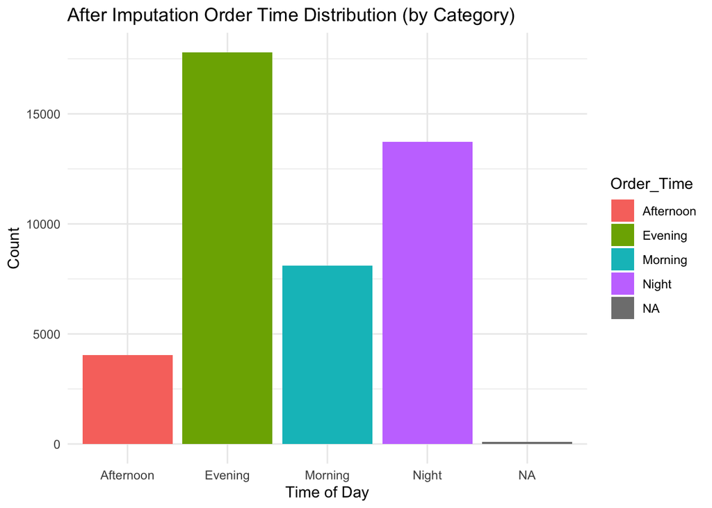

```r
amazon <- amazon %>%
  mutate(Order_Time = case_when(
    !is.na(Order_Time) & hour(Order_Time) < 12 ~ "Morning",
    !is.na(Order_Time) & hour(Order_Time) < 17 ~ "Afternoon",
    !is.na(Order_Time) & hour(Order_Time) < 21 ~ "Evening",
    !is.na(Order_Time) ~ "Night",
    TRUE ~ NA_character_
  ))

amazon$Order_Time <- as.factor(amazon$Order_Time)

ggplot(amazon, aes(x = Order_Time, fill = Order_Time)) +
  geom_bar() +
  labs(title = "After Imputation Order Time Distribution (by Category)",
       x = "Time of Day", y = "Count") +
  theme_minimal()
```

After exploring the missingness mechanism, it was seen that the missing values in *Weather, Traffic, and Order_Time* (converted to time-of-day categories) are likely Missing At Random (MAR), while the missing values in *Agent_Rating* are likely Missing Completely At Random (MCAR). Based on this classification, a multiple imputation method was selected.

The MICE (Multiple Imputation by Chained Equations) method was used with predictive mean matching (PMM). This method was chosen because it allows imputing missing values by using patterns from other variables in the dataset. Since the MAR and MCAR assumptions are suitable for MICE, it is a reliable and widely used method in such cases.

To enable MICE-based imputation, *Order_Time* was transformed from continuous time into a categorical variable with four bins: Morning, Afternoon, Evening, and Night. This transformation aligned with typical order behavior and made the variable suitable for categorical imputation. This decision was made because Order_Time contains missing values and may be useful in the later stages of the project. By converting it into a factor, it was possible to impute its missing values meaningfully within the MICE framework. Along with Order_Time, the variables *Agent_Rating, Weather, and Traffic* were also included in the imputation model. The *Pickup_Time* variable was excluded from this process not because it had missing values, but because its time format was not compatible with MICE.

```r
amazon_mice <- amazon %>%
  select(-Pickup_Time)

imp_data <- mice(amazon_mice, m = 5, method = "pmm", seed = 412)
amazon_imputed <- complete(imp_data, 1)
```

# MICE Imputation Before - After Visualization

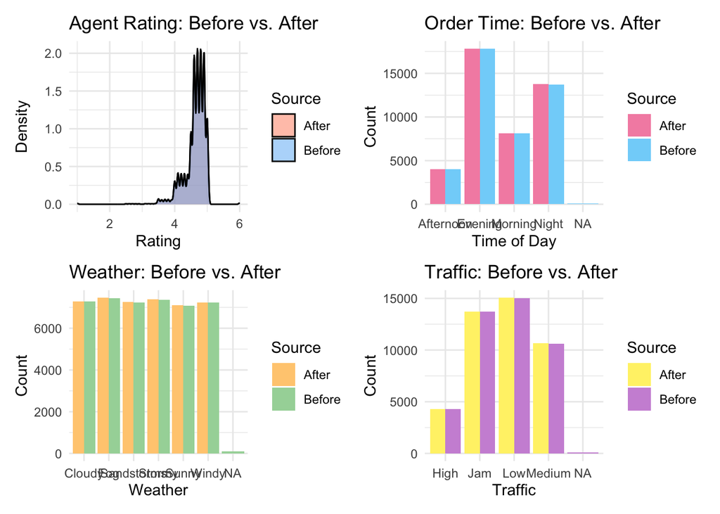

```r
library(ggplot2)
library(patchwork)
library(forcats)

df_rating_compare <- data.frame(
  Rating = c(amazon$Agent_Rating, amazon_imputed$Agent_Rating),
  Source = rep(c("Before", "After"), each = nrow(amazon))
)

p1 <- ggplot(df_rating_compare, aes(x = Rating, fill = Source)) +
  geom_density(alpha = 0.5) +
  scale_fill_manual(values = c("Before" = "#64B5F6", "After" = "#FF8A65")) +
  labs(title = "Agent Rating: Before vs. After", x = "Rating", y = "Density") +
  theme_minimal()

df_time_compare <- data.frame(
  Time = c(as.character(amazon$Order_Time), as.character(amazon_imputed$Order_Time)),
  Source = rep(c("Before", "After"), each = nrow(amazon))
)

p2 <- ggplot(df_time_compare, aes(x = Time, fill = Source)) +
  geom_bar(position = "dodge") +
  scale_fill_manual(values = c("Before" = "#81D4FA", "After" = "#F48FB1")) +
  labs(title = "Order Time: Before vs. After", x = "Time of Day", y = "Count") +
  theme_minimal()

df_weather_compare <- data.frame(
  Weather = c(as.character(amazon$Weather), as.character(amazon_imputed$Weather)),
  Source = rep(c("Before", "After"), each = nrow(amazon))
)

p3 <- ggplot(df_weather_compare, aes(x = Weather, fill = Source)) +
  geom_bar(position = "dodge") +
  scale_fill_manual(values = c("Before" = "#A5D6A7", "After" = "#FFCC80")) +
  labs(title = "Weather: Before vs. After", x = "Weather", y = "Count") +
  theme_minimal()

df_traffic_compare <- data.frame(
  Traffic = c(as.character(amazon$Traffic), as.character(amazon_imputed$Traffic)),
  Source = rep(c("Before", "After"), each = nrow(amazon))
)

p4 <- ggplot(df_traffic_compare, aes(x = Traffic, fill = Source)) +
  geom_bar(position = "dodge") +
  scale_fill_manual(values = c("Before" = "#CE93D8", "After" = "#FFF176")) +
  labs(title = "Traffic: Before vs. After", x = "Traffic", y = "Count") +
  theme_minimal()

(p1 | p2) / (p3 | p4)
```

To evaluate the performance and consistency of the imputation process, the variables that initially contained missing values *Agent_Rating, Order_Time, Weather, and Traffic* were visualized before and after applying MICE.

The density plot for *Agent_Rating* shows that the distribution remained consistent, indicating that the imputed values did not distort the original structure. The bar plots for *Order_Time, Weather, and Traffic* further demonstrate that the categorical distributions were preserved. The disappearance of the NA bars in the “After” plots confirms that all missing values were successfully imputed.

These visual validations support the appropriateness of using MICE with Predictive Mean Matching and confirm that the integrity of the dataset was maintained.

## 5. Data Manipulation, Feature Engineering

# Distance

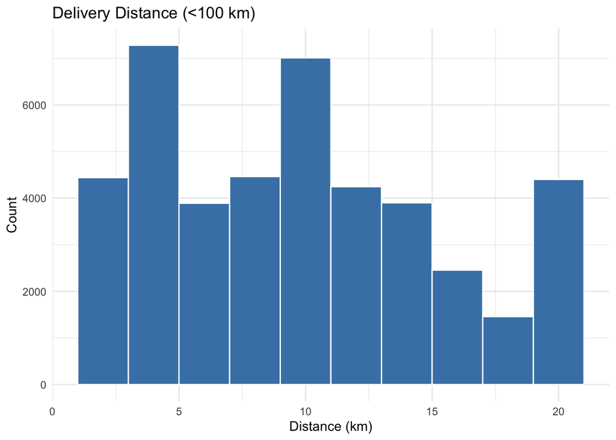

```r
haversine <- function(lat1, lon1, lat2, lon2) {
  R <- 6371  # km
  to_rad <- function(deg) deg * pi / 180

  lat1 <- to_rad(lat1)
  lon1 <- to_rad(lon1)
  lat2 <- to_rad(lat2)
  lon2 <- to_rad(lon2)

  dlat <- lat2 - lat1
  dlon <- lon2 - lon1

  a <- sin(dlat / 2)^2 + cos(lat1) * cos(lat2) * sin(dlon / 2)^2
  c <- 2 * asin(sqrt(a))

  R * c
}
haversine_vec <- Vectorize(haversine)
amazon_imputed <- amazon_imputed %>%
  mutate(Distance_km = haversine_vec(Store_Latitude, Store_Longitude,
                                     Drop_Latitude, Drop_Longitude))

amazon_imputed %>%
  filter(Distance_km < 100) %>%
  ggplot(aes(x = Distance_km)) +
  geom_histogram(binwidth = 2, fill = "steelblue", color = "white") +
  labs(title = "Delivery Distance (<100 km)", x = "Distance (km)", y = "Count") +
  theme_minimal()
```

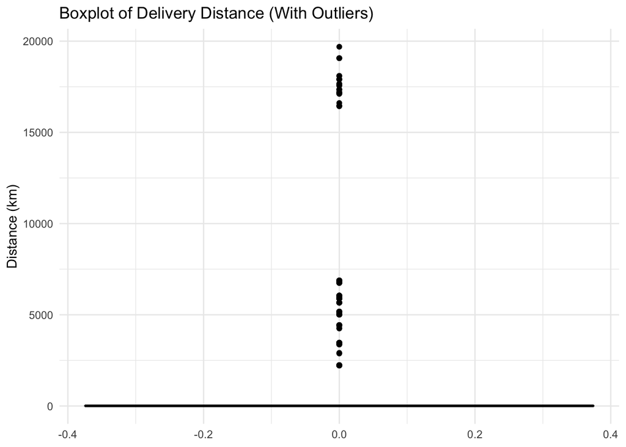

```r
Q1 <- quantile(amazon_imputed$Distance_km, 0.25, na.rm = TRUE)
Q3 <- quantile(amazon_imputed$Distance_km, 0.75, na.rm = TRUE)
IQR_val <- Q3 - Q1
lower_bound <- Q1 - 1.5 * IQR_val
upper_bound <- Q3 + 1.5 * IQR_val

ggplot(amazon_imputed, aes(y = Distance_km)) +
  geom_boxplot(fill = "salmon", color = "black") +
  labs(title = "Boxplot of Delivery Distance (With Outliers)",
       y = "Distance (km)") +
  theme_minimal()
```

```r
sum(amazon_imputed$Distance_km < lower_bound, na.rm = TRUE)
```

```
## [1] 0
```

```r
sum(amazon_imputed$Distance_km > upper_bound, na.rm = TRUE)
```

```
## [1] 188
```

To analyze the spatial effects on delivery time and logistics performance under the title of Feature Engineering, a new variable named Distance_km which represents the physical distance between the store and delivery points was created. This variable was calculated using the haversine formula with latitude and longitude coordinates, expressed in kilometers.

Upon examining the distribution of delivery distances, it was noticed that some values with high distances significantly distorted the distribution. It is believed that these outliers are likely a result of coordinate errors made during data entry. To identify these outliers, we applied the Interquartile Range (IQR) method and created a Boxplot visualization.Based on the outlier analysis using the IQR method, a total of 188 observations exceeded the upper threshold for this variable and were classified as potential outliers.

This variable will be utilized in the modeling process, especially for estimating delivery times and analyzing efficiency.

# Delivery Category

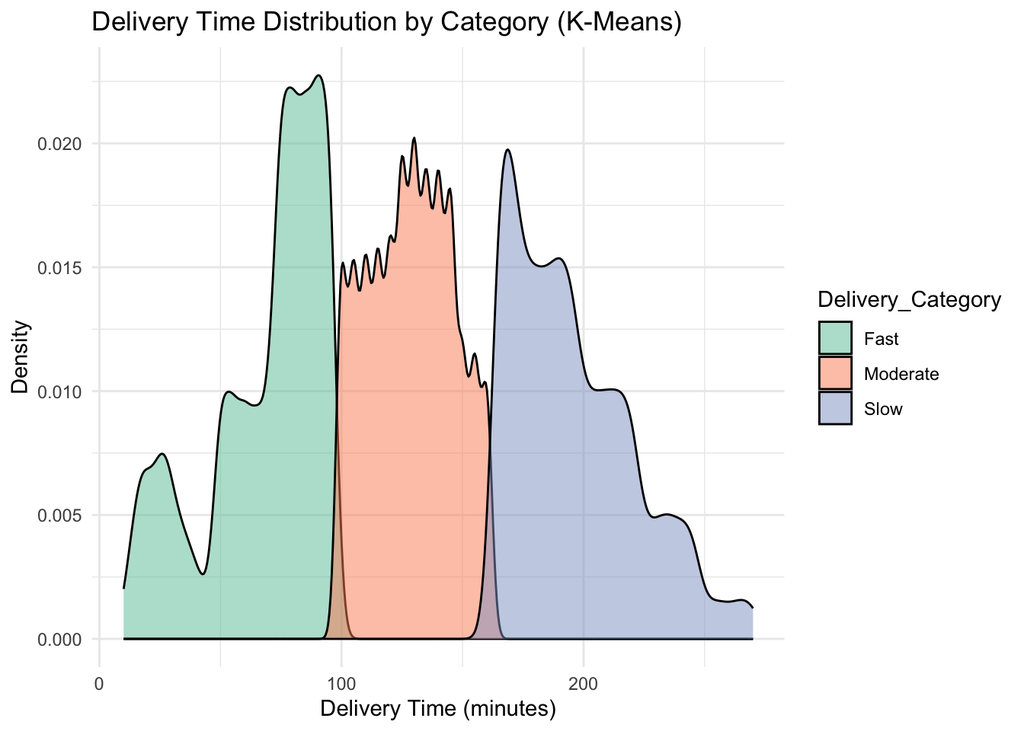

```r
set.seed(412)
kmeans_model <- kmeans(amazon_imputed$Delivery_Time, centers = 3, nstart = 25)
amazon_imputed$Delivery_Cluster <- kmeans_model$cluster

cluster_order <- amazon_imputed %>%
  group_by(Delivery_Cluster) %>%
  summarise(mean_time = mean(Delivery_Time, na.rm = TRUE)) %>%
  arrange(mean_time) %>%
  mutate(Delivery_Category = c("Fast", "Moderate", "Slow"))

amazon_imputed <- amazon_imputed %>%
  left_join(cluster_order, by = "Delivery_Cluster")


ggplot(amazon_imputed, aes(x = Delivery_Time, fill = Delivery_Category)) +
  geom_density(alpha = 0.5) +
  labs(title = "Delivery Time Distribution by Category (K-Means)",
       x = "Delivery Time (minutes)", y = "Density") +
  scale_fill_brewer(palette = "Set2") +
  theme_minimal()
```

## 6. Confirmatory Data Analysis

### 1. Hypothesis: Delivery Time differs by Traffic Conditions

Based on the EDA results, it appeared that delivery time differs across traffic levels. To test this observation formally, a Kruskal-Wallis rank sum test was conducted.

```r
kruskal.test(Delivery_Time ~ Traffic, data = amazon_imputed)
```

```
##
##  Kruskal-Wallis rank sum test
##
## data:  Delivery_Time by Traffic
## Kruskal-Wallis chi-squared = 6134.6, df = 3, p-value < 2.2e-16
```

The test returned a p-value far below the 0.05 significance level, leading to the rejection of the null hypothesis. This confirms that delivery time significantly differs across traffic conditions. The result supports the EDA insight that jammed traffic is associated with longer delivery durations.

```r
kruskal.test(Delivery_Time ~ Traffic, data = amazon_imputed)
```

[output not shown]

### 3. Hypothesis: Delivery Time differs by Area

EDA results suggested that delivery time may vary depending on the delivery area. Semi-Urban regions, in particular, appeared to have higher median delivery durations. To test whether these observed differences are statistically significant, a Kruskal-Wallis rank sum test was conducted.

```r
kruskal.test(Delivery_Time ~ Area, data = amazon_imputed)
```

```
##
##  Kruskal-Wallis rank sum test
##
## data:  Delivery_Time by Area
## Kruskal-Wallis chi-squared = 1878.2, df = 3, p-value < 2.2e-16
```

The p-value is far below 0.05, we reject the null hypothesis. This confirms that delivery time significantly differs across area types. The result supports the earlier EDA findings, where Semi-Urban areas showed longer delivery durations compared to Urban and Metropolitian regions.

### 4. Hypothesis: Delivery Time differs by Time of Order

```r
kruskal.test(Delivery_Time ~ Order_Time, data = amazon_imputed)
```

```
##
##  Kruskal-Wallis rank sum test
##
## data:  Delivery_Time by Order_Time
## Kruskal-Wallis chi-squared = 3358.6, df = 3, p-value < 2.2e-16
```

### 5. Hypothesis: Relationship between Agent Rating, Agent Age and Delivery Time

```r
cor.test(amazon_imputed$Delivery_Time, amazon_imputed$Agent_Rating, method = "spearman")
```

```
##
##  Spearman's rank correlation rho
##
## data:  amazon_imputed$Delivery_Time and amazon_imputed$Agent_Rating
## S = 1.7571e+13, p-value < 2.2e-16
## alternative hypothesis: true rho is not equal to 0
## sample estimates:
##        rho
## -0.2598979
```

```r
cor.test(amazon_imputed$Delivery_Time, amazon_imputed$Agent_Age, method = "spearman")
```

```
##
##  Spearman's rank correlation rho
##
## data:  amazon_imputed$Delivery_Time and amazon_imputed$Agent_Age
## S = 1.0137e+13, p-value < 2.2e-16
## alternative hypothesis: true rho is not equal to 0
## sample estimates:
##       rho
## 0.2731536
```

The correlation between Delivery_Time and Agent_Rating was ρ = -0.26 with a p-value < 2.2e-16.

This indicates a statistically significant negative correlation, suggesting that higher-rated agents tend to deliver more quickly. The correlation between Delivery_Time and Agent_Age was ρ = 0.27 with a p-value < 2.2e-16.

This indicates a statistically significant positive correlation, meaning that older agents tend to take slightly longer to complete deliveries.

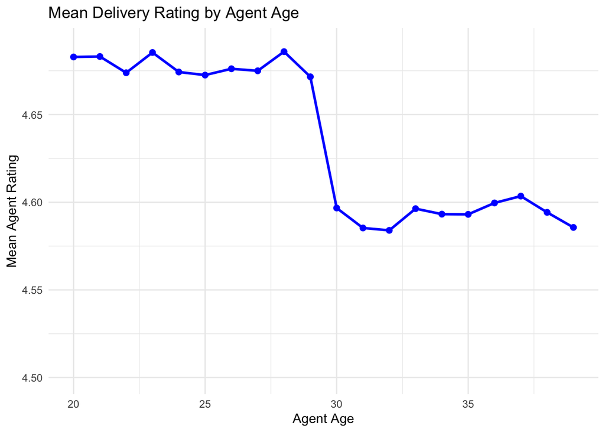

```r
library(ggplot2)
library(dplyr)

amazon_imputed <- amazon_imputed %>%
  filter(Agent_Rating <= 5)

rating_by_age <- amazon_imputed %>%
  group_by(Agent_Age) %>%
  summarise(Mean_Rating = mean(Agent_Rating, na.rm = TRUE)) %>%
  filter(Agent_Age >= 20, Agent_Age <= 39)

ggplot(rating_by_age, aes(x = Agent_Age, y = Mean_Rating)) +
  geom_line(color = "blue", linewidth = 1) +
  geom_point(color = "blue", size = 2) +
  scale_y_continuous(limits = c(4.50, 4.69)) +
  labs(
    title = "Mean Delivery Rating by Agent Age",
    x = "Agent Age",
    y = "Mean Agent Rating"
  ) +
  theme_minimal()
```

After investigating the correlations between Delivery_Time and both Agent_Rating and Agent_Age, we explored the potential relationship between agent age and rating to understand how these two characteristics might interact.

## 7. Cross-validation, Train-test Split

To evaluate model performance in a reliable and unbiased way, 5-fold cross-validation was applied.The dataset was split into 5 equal parts, where each fold was used once as a test set while the remaining were used for training. A fixed seed (set.seed(412)) was used to ensure reproducibility. A CART (Classification and Regression Tree) model was trained.

```r
library(caret)
library(rpart)
set.seed(412)

cv_control <- trainControl(method = "cv", number = 5)
cv_model <- train(
  Delivery_Time ~ .,
  data = amazon_imputed,
  method = "rpart",
  trControl = cv_control
)

print(cv_model)
```

```
## CART
##
## 43686 samples
##    17 predictor
##
## No pre-processing
## Resampling: Cross-Validated (5 fold)
## Summary of sample sizes: 34948, 34950, 34948, 34949, 34949
## Resampling results across tuning parameters:
##
##   cp          RMSE      Rsquared   MAE
##   0.04791745  19.75554  0.8542737  16.07137
##   0.25815510  31.77223  0.6161390  25.82169
##   0.56787117  34.26304  0.5645151  27.82471
##
## RMSE was used to select the optimal model using the smallest value.
## The final value used for the model was cp = 0.04791745.
```

During cross-validation, the model was evaluated across three different values of the complexity parameter (cp), which controls tree pruning and complexity.The optimal value of the tuning parameter was selected based on the lowest RMSE value, which corresponded to cp = 0.0479. This model was chosen as the final model for subsequent evaluation and interpretation.

## 8. Statistical Modeling for Prediction

A Classification and Regression Tree (CART) model was trained to predict delivery time based on various features such as agent characteristics, environmental conditions, location, and order details.

The model was trained using 5-fold cross-validation, and the best complexity parameter was selected based on the lowest RMSE. The final selected model had cp = 0.0479.

### Variable Importance

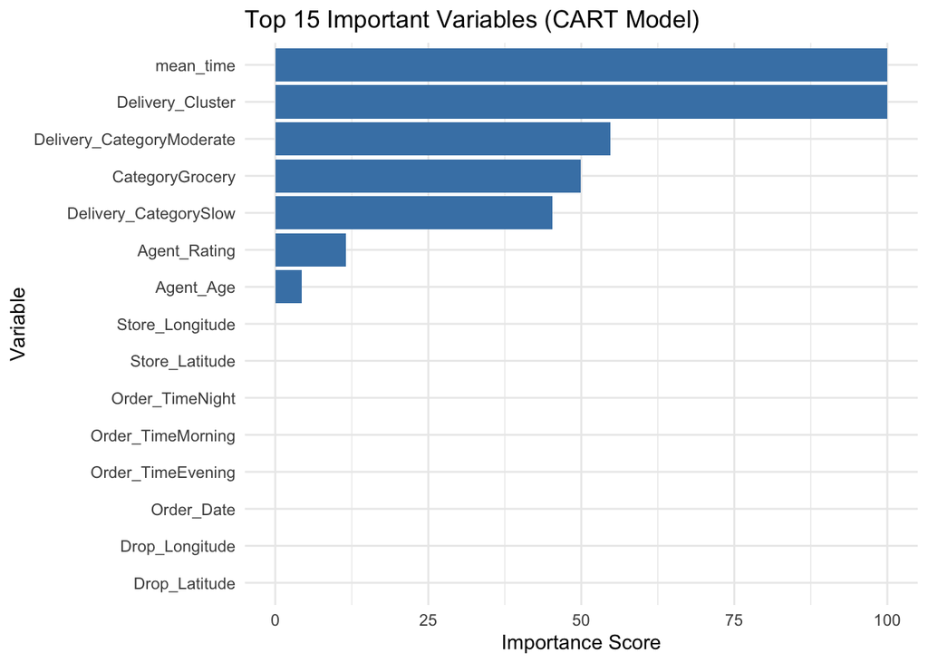

```r
library(ggplot2)
importance_df <- varImp(cv_model)$importance
importance_df$Variable <- rownames(importance_df)
top_vars <- importance_df[order(-importance_df$Overall), ][1:15, ]

ggplot(top_vars, aes(x = reorder(Variable, Overall), y = Overall)) +
  geom_col(fill = "steelblue") +
  coord_flip() +
  labs(title = "Top 15 Important Variables (CART Model)",
       x = "Variable", y = "Importance Score") +
  theme_minimal()
```